# Gradient Boosting

## Introduction

[Gradient boosting](https://en.wikipedia.org/wiki/Gradient_boosting) is a machine learning technique for regression and classification problems, which produces a prediction model in the form of an ensemble of weak prediction models, typically decision trees. It builds the model in an iterative fashion like other boosting methods do, and it generalizes them by allowing optimization of an arbitrary differentiable loss function.

It is recommended that you read through the accompanying Classification and Regression Trees Tutorial for an overview of decision trees.

## History

Boosting is one of the most powerful learning ideas introduced in the last twenty years. It was originally designed for classification problems, but it can be extended to regression as well. The motivation for boosting was a procedure that combines the outputs of many “weak” classifiers to produce a powerful “committee.” A weak classifier (e.g. decision tree) is one whose error rate is only slightly better than random guessing.

AdaBoost short for “Adaptive Boosting”, is a machine learning meta-algorithm formulated by [Yoav Freund](https://en.wikipedia.org/wiki/Yoav_Freund) and [Robert Schapire](https://en.wikipedia.org/wiki/Robert_Schapire) in 1996, which is now considered to be a special case of Gradient Boosting. There are [some differences](http://stats.stackexchange.com/questions/164233/intuitive-%20explanations-of-differences-between-gradient-boosting-trees-gbm-ad) between the AdaBoost algorithm and modern Gradient Boosting. In the AdaBoost algorithm, the “shortcomings” of existing weak learners are identified by high-weight data points, however in Gradient Boosting, the shortcomings are identified by gradients.

The idea of gradient boosting originated in the observation by Leo Breiman that boosting can be interpreted as an optimization algorithm on a suitable cost function. Explicit regression gradient boosting algorithms were subsequently developed by Jerome H. Friedman, simultaneously with the more general functional gradient boosting perspective of Llew Mason, Jonathan Baxter, Peter Bartlett and Marcus Frean. The latter two papers introduced the abstract view of boosting algorithms as iterative functional gradient descent algorithms. That is, algorithms that optimize a cost function over function space by iteratively choosing a function (weak hypothesis) that points in the negative gradient direction. This functional gradient view of boosting has led to the development of boosting algorithms in many areas of machine learning and statistics beyond regression and classification.

## Gradient Boosting

[Gradient boosting](https://en.wikipedia.org/wiki/Gradient_boosting) is a machine learning technique for regression and classification problems, which produces a prediction model in the form of an ensemble of weak prediction models, typically decision trees. It builds the model in a stage-wise fashion like other boosting methods do, and it generalizes them by allowing optimization of an arbitrary differentiable loss function.

The purpose of boosting is to sequentially apply the weak classification algorithm to repeatedly modified versions of the data, thereby producing a sequence of weak classifiers $G_m(x)$, $m = 1, 2, ... , M$.

## Housing Data Manipulation/Preprocessing

```r
#library(readr)
train <- read.csv("//user/home/loecherm/DropboxHWR/PreviousSemesters/SS2017/AnalyticsLab/data/kaggle/HousePrices/train.csv.gz")
test <- read.csv("//user/home/loecherm/DropboxHWR/PreviousSemesters/SS2017/AnalyticsLab/data/kaggle/HousePrices/test.csv.gz")
```

```r
cat_var <- names(train)[which(sapply(train, is.factor))]
cat_car <- unique(c(cat_var, 'BedroomAbvGr', 'HalfBath', ' KitchenAbvGr','BsmtFullBath', 'BsmtHalfBath', 'MSSubClass'))
numeric_var <- names(train)[which(sapply(train, is.numeric))]
```

#### Structure of the data

The housing data set has 1460 rows and 81 features with the target feature Sale Price.

For now we remove all columns with missing variables

Create new target variable logSale

```r
test$SalePrice = NA
train$logSale = log(train$SalePrice)
test$logSale = log(test$SalePrice)
```

```r
#setdiff(colnames(train), colnames(test))

train = train[,intersect(colnames(train), colnames(test))]

jj = is.na(train$SalePrice)
train$SalePrice[jj] = mean(train$SalePrice, na.rm=TRUE)
#remove NAs
mv = colSums(sapply(train, is.na))
train = train[,mv==0]

test = test[,intersect(colnames(train), colnames(test))]

allData = rbind.data.frame(train,test)
nTRain=nrow(train)
nTest=nrow(test)

cat_car = intersect(cat_car, colnames(allData))

for (catCol in cat_car){
   levels(train[,catCol]) = levels(allData[,catCol])
   levels(test[,catCol]) = levels(allData[,catCol])
}
```

## Iterative Model Improvement:

What is the idea behind this procedure? Unlike fitting a single large decision tree to the data, which amounts to fitting the data hard and potentially overfitting, the boosting approach instead learns slowly. Given the current model, we fit a decision tree to the residuals from the model. That is, we fit a tree using the current residuals, rather than the outcome Y , as the response. We then add this new decision tree into the fitted function in order to update the residuals. Each of these trees can be rather small, with just a few terminal nodes, determined by the parameter d in the algorithm.

Let us try this method on a linear model first:

1. Fit a linear regression $y_i = \beta_0 + \sum{\beta_j x_{i, j} + u_i$ and obtain residuals as $r_i = y_i - \hat{y}_i$.
2. Fit a linear regression on the residuals: $r_i = \beta_0 + \sum{\beta_j x_{i, j} + u_i$ and update both the estimate as well as the residuals!
3. Repeat as long as you need to.

```r
fit0 = lm(logSale ~ LotArea + BedroomAbvGr + factor(YrSold), data = train)
cat("R2 = ", round(summary(fit0)$r.squared, 4))
```

```
## R2 =  0.0995
```

```r
yHat0 = fit0$fitted.values
cat("R = ", round(cor(yHat0, train$logSale), 4), "\n")
```

```
## R =  0.3154
```

```r
res0 = residuals(fit0)
```

1st Iteration

```r
res1= res0 #train$logSale
yHat1 = yHat0 #0

for (i in 1:5){
  train$residuals = res1

  fit1 = lm(residuals ~ LotArea + BedroomAbvGr + factor(YrSold), data = train)
  #summary(fit1)$r.squared

  yHat1 = yHat1 + fit1$fitted.values
  cat(i, "th, iteration, R = ", round(cor(exp(yHat1), exp(train$logSale)), 4), "\n")
  res1 = residuals(fit1)
}
```

```
## 1 th, iteration, R =  0.2121
## 2 th, iteration, R =  0.2121
## 3 th, iteration, R =  0.2121
## 4 th, iteration, R =  0.2121
## 5 th, iteration, R =  0.2121
```

## Modifiy the above into a tree based boosting algorithm

[output not shown]

## Modifiy the above such that we return an actual model, which we can deploy in a train/test situation:

```r
set.seed(123)
iTrain =sample(nrow(train), round(3*nrow(train)/4))


boostedTrees = myBoost(train[iTrain,],d=2)
```

```
## 1 th, iteration, R =  0.8941
## 2 th, iteration, R =  0.9438
## 3 th, iteration, R =  0.9496
## 4 th, iteration, R =  0.9638
## 5 th, iteration, R =  0.9738
## 6 th, iteration, R =  0.9796
## 7 th, iteration, R =  0.9805
## 8 th, iteration, R =  0.9879
## 9 th, iteration, R =  0.9879
## 10 th, iteration, R =  0.9891
```

```r
#first double check the training error:
myPredict(boostedTrees,train[iTrain,])
```

```
## 1 th, iteration, R =  0.8941
## 2 th, iteration, R =  0.9438
## 3 th, iteration, R =  0.9496
## 4 th, iteration, R =  0.9638
## 5 th, iteration, R =  0.9738
## 6 th, iteration, R =  0.9796
## 7 th, iteration, R =  0.9805
## 8 th, iteration, R =  0.9879
## 9 th, iteration, R =  0.9879
## 10 th, iteration, R =  0.9891
```

```r
#now  check the test error:
myPredict(boostedTrees,train[-iTrain,])
```

```
## 1 th, iteration, R =  0.9243
## 2 th, iteration, R =  0.9465
## 3 th, iteration, R =  0.9519
## 4 th, iteration, R =  0.9715
## 5 th, iteration, R =  0.9793
## 6 th, iteration, R =  0.9874
## 7 th, iteration, R =  0.9882
## 8 th, iteration, R =  0.9882
## 9 th, iteration, R =  0.9882
## 10 th, iteration, R =  0.9901
```

##### Boosting has (at least) four tuning parameters:

1. The number of trees B. Unlike bagging and random forests, boosting can overfit if B is too large, although this overfitting tends to occur slowly if at all. We use cross-validation to select B.
2. The shrinkage parameter $\lambda$, a small positive number. This controls the rate at which boosting learns. Typical values are 0.01 or 0.001, and the right choice can depend on the problem. Very small $\lambda$ can require using a very large value of B in order to achieve good performance.
3. The number d of splits in each tree, which controls the complexity of the boosted ensemble. Often d = 1 works well, in which case each tree is a stump, consisting of a single split. In this case, the boosted ensemble is fitting an additive model, since each term involves only a single variable. More generally d is the interaction depth, and controls the interaction order of the boosted model, since d splits can involve at most d variables.
4. subsampling rate

## Stochastic GBM

[Stochastic Gradient Boosting](https://statweb.stanford.edu/~jhf/ftp/stobst.pdf) (Friedman, 2002) proposed the stochastic gradient boosting algorithm that simply samples uniformly without replacement from the dataset before estimating the next gradient step. He found that this additional step greatly improved performance.

Create some data with missing values and factors:

```r
set.seed(123)
N <- 1000
X1 <- runif(N)
X2 <- 2*runif(N)
X3 <- ordered(sample(letters[1:4],N,replace=TRUE),levels=letters[4:1])
X4 <- factor(sample(letters[1:6],N,replace=TRUE))
X5 <- factor(sample(letters[1:3],N,replace=TRUE))
X6 <- 3*runif(N)
mu <- c(-1,0,1,2)[as.numeric(X3)]

SNR <- 10 # signal-to-noise ratio
Y <- X1**1.5 + 2 * (X2**.5) + mu
sigma <- sqrt(var(Y)/SNR)
Y <- Y + rnorm(N,0,sigma)

# introduce some missing values
X1[sample(1:N,size=500)] <- NA
X4[sample(1:N,size=300)] <- NA

data <- data.frame(Y=Y,X1=X1,X2=X2,X3=X3,X4=X4,X5=X5,X6=X6)
```

```r
# fit initial model
gbm1 <-
gbm(Y~X1+X2+X3+X4+X5+X6,         # formula
    data=data,                   # dataset
    var.monotone=c(0,0,0,0,0,0), # -1: monotone decrease,
                                 # +1: monotone increase,
                                 #  0: no monotone restrictions
    distribution="gaussian",     # see the help for other choices
    n.trees=400,                # number of trees
    shrinkage=0.05,              # shrinkage or learning rate,
                                 # 0.001 to 0.1 usually work
    interaction.depth=3,         # 1: additive model, 2: two-way interactions, etc.
    bag.fraction = 0.5,          # subsampling fraction, 0.5 is probably best
    train.fraction = 0.5,        # fraction of data for training,
                                 # first train.fraction*N used for training
    n.minobsinnode = 10,         # minimum total weight needed in each node
    cv.folds = 3,                # do 3-fold cross-validation
    keep.data=TRUE,              # keep a copy of the dataset with the object
    verbose=FALSE)#,               # don't print out progress
    #n.cores=1)                   # use only a single core (detecting #cores is
                                 # error-prone, so avoided here)
```

```r
# check performance using an out-of-bag estimator
# OOB underestimates the optimal number of iterations
best.iter <- gbm.perf(gbm1,method="OOB")
```

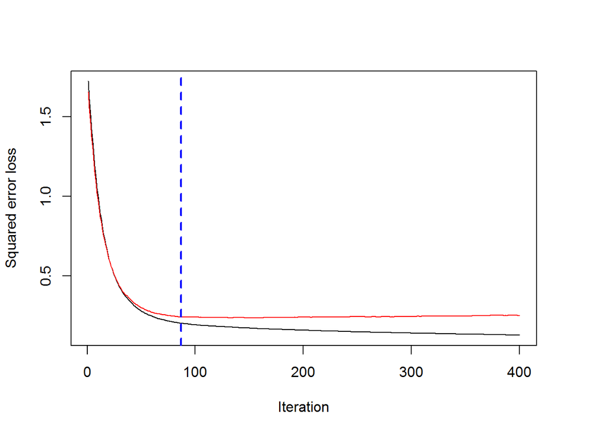

```r
print(best.iter)
```

```
## [1] 87
```

```r
# check performance using a 50% heldout test set
best.iter <- gbm.perf(gbm1,method="test")
```

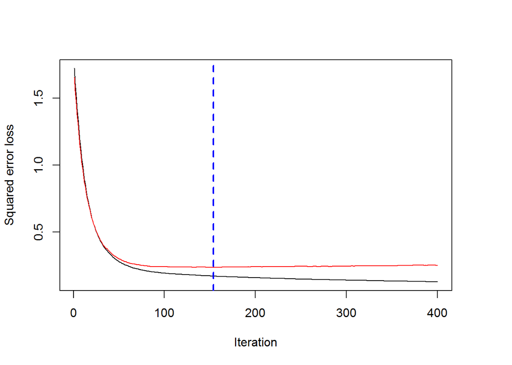

```r
print(best.iter)
```

```
## [1] 154
```

```r
# check performance using cross-validation
best.iter <- gbm.perf(gbm1,method="cv")
```

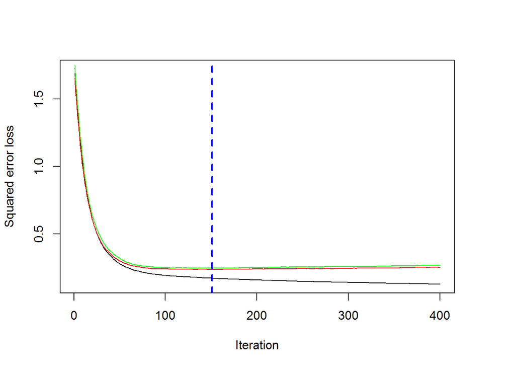

```r
print(best.iter)
```

```
## [1] 151
```

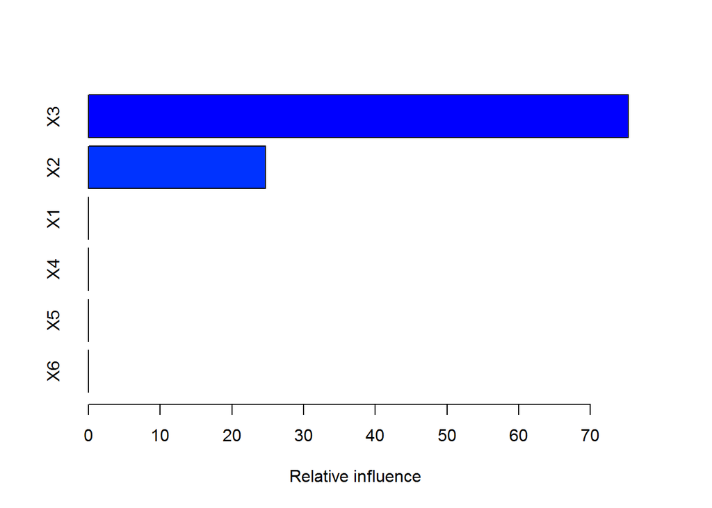

```
##    var  rel.inf
## X3  X3 75.32317
## X2  X2 24.67683
## X1  X1  0.00000
## X4  X4  0.00000
## X5  X5  0.00000
## X6  X6  0.00000
```

```r
# plot the performance # plot variable influence
summary(gbm1,n.trees=1)         # based on the first tree
```

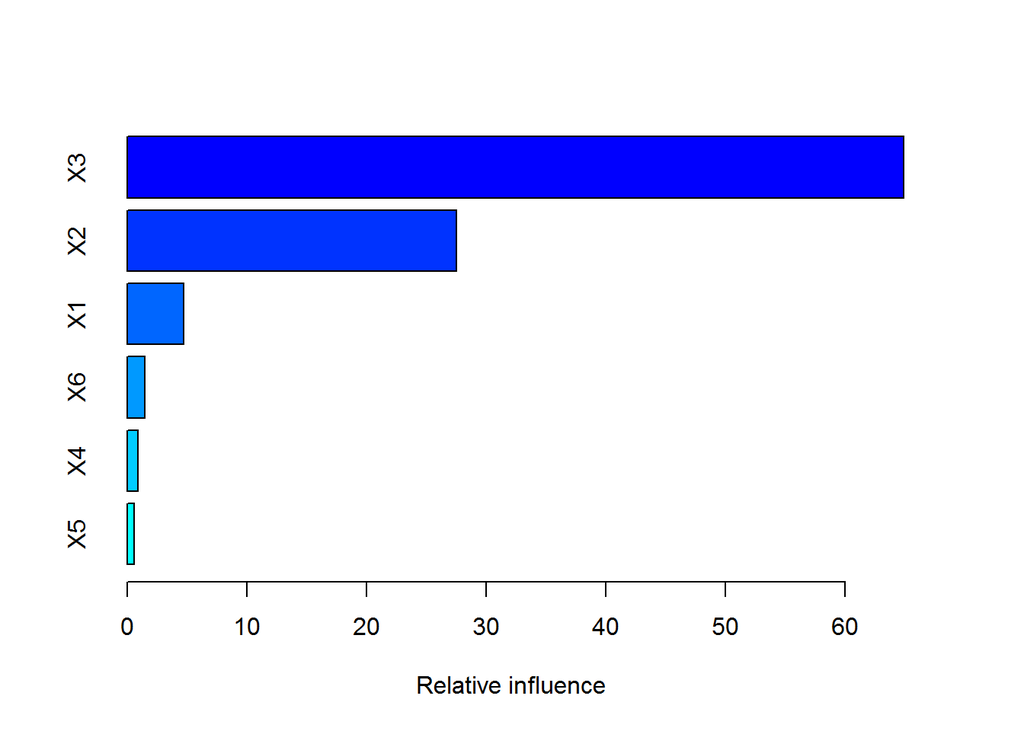

```
##    var    rel.inf
## X3  X3 64.9005664
## X2  X2 27.5012005
## X1  X1  4.7047039
## X6  X6  1.4367261
## X4  X4  0.9014071
## X5  X5  0.5553961
```

```r
summary(gbm1,n.trees=best.iter) # based on the estimated best number of trees
```

```r
# compactly print the first and last trees for curiosity
print(pretty.gbm.tree(gbm1,1))
```

```
##   SplitVar SplitCodePred LeftNode RightNode MissingNode ErrorReduction
## 0        2  1.5000000000        1         5           9      233.04255
## 1        1  1.1619616512        2         3           4       28.92649
## 2       -1 -0.0708736344       -1        -1          -1        0.00000
## 3       -1 -0.0216416771       -1        -1          -1        0.00000
## 4       -1 -0.0498895215       -1        -1          -1        0.00000
## 5        1  0.5002437991        6         7           8       47.42122
## 6       -1 -0.0039156939       -1        -1          -1        0.00000
## 7       -1  0.0649904551       -1        -1          -1        0.00000
## 8       -1  0.0466872592       -1        -1          -1        0.00000
## 9       -1 -0.0004422097       -1        -1          -1        0.00000
##   Weight    Prediction
## 0    250 -0.0004422097
## 1    122 -0.0498895215
## 2     70 -0.0708736344
## 3     52 -0.0216416771
## 4    122 -0.0498895215
## 5    128  0.0466872592
## 6     34 -0.0039156939
## 7     94  0.0649904551
## 8    128  0.0466872592
## 9    250 -0.0004422097
```

```r
print(pretty.gbm.tree(gbm1,gbm1$n.trees))
```

```
##   SplitVar SplitCodePred LeftNode RightNode MissingNode ErrorReduction
## 0        1  1.6285244727        1         8           9      0.4067607
## 1        1  0.3750580421        2         3           7      0.5814755
## 2       -1 -0.0035453363       -1        -1          -1      0.0000000
## 3        0  0.5879460601        4         5           6      0.6927610
## 4       -1  0.0049032080       -1        -1          -1      0.0000000
## 5       -1 -0.0040321814       -1        -1          -1      0.0000000
## 6       -1  0.0037789392       -1        -1          -1      0.0000000
## 7       -1  0.0010966731       -1        -1          -1      0.0000000
## 8       -1 -0.0043501643       -1        -1          -1      0.0000000
## 9       -1  0.0002033918       -1        -1          -1      0.0000000
##   Weight    Prediction
## 0    250  0.0002033918
## 1    209  0.0010966731
## 2     51 -0.0035453363
## 3    158  0.0025950432
## 4     49  0.0049032080
## 5     31 -0.0040321814
## 6     78  0.0037789392
## 7    209  0.0010966731
## 8     41 -0.0043501643
## 9    250  0.0002033918
```

### Performance on test data:

```r
# make some new data
set.seed(321)
N <- 1000
X1 <- runif(N)
X2 <- 2*runif(N)
X3 <- ordered(sample(letters[1:4],N,replace=TRUE))
X4 <- factor(sample(letters[1:6],N,replace=TRUE))
X5 <- factor(sample(letters[1:3],N,replace=TRUE))
X6 <- 3*runif(N)
mu <- c(-1,0,1,2)[as.numeric(X3)]

Y <- X1**1.5 + 2 * (X2**.5) + mu + rnorm(N,0,sigma)

data2 <- data.frame(Y=Y,X1=X1,X2=X2,X3=X3,X4=X4,X5=X5,X6=X6)

# predict on the new data using "best" number of trees
# f.predict generally will be on the canonical scale (logit,log,etc.)
f.predict <- predict(gbm1,data2,best.iter)

# least squares error
print(sum((data2$Y-f.predict)^2))
```

```
## [1] 5070.606
```

### marginal plots

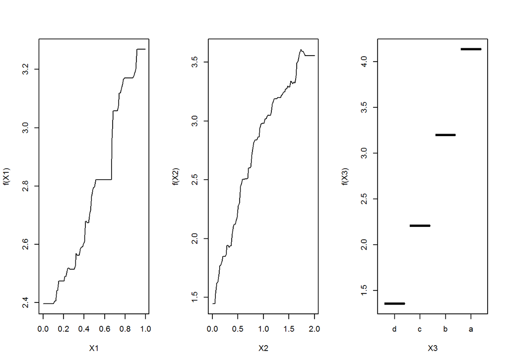

```r
# create marginal plots
# plot variable X1,X2,X3 after "best" iterations
par(mfrow=c(1,3))
plot(gbm1,1,best.iter)
plot(gbm1,2,best.iter)
plot(gbm1,3,best.iter)
```

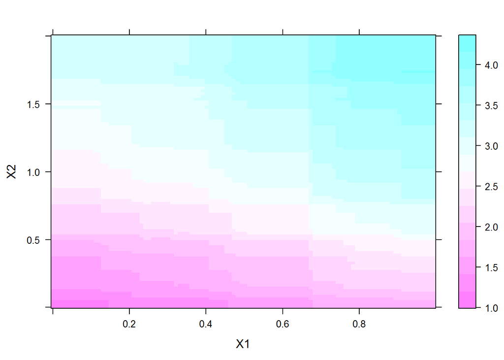

```r
par(mfrow=c(1,1))
# contour plot of variables 1 and 2 after "best" iterations
plot(gbm1,1:2,best.iter)
```

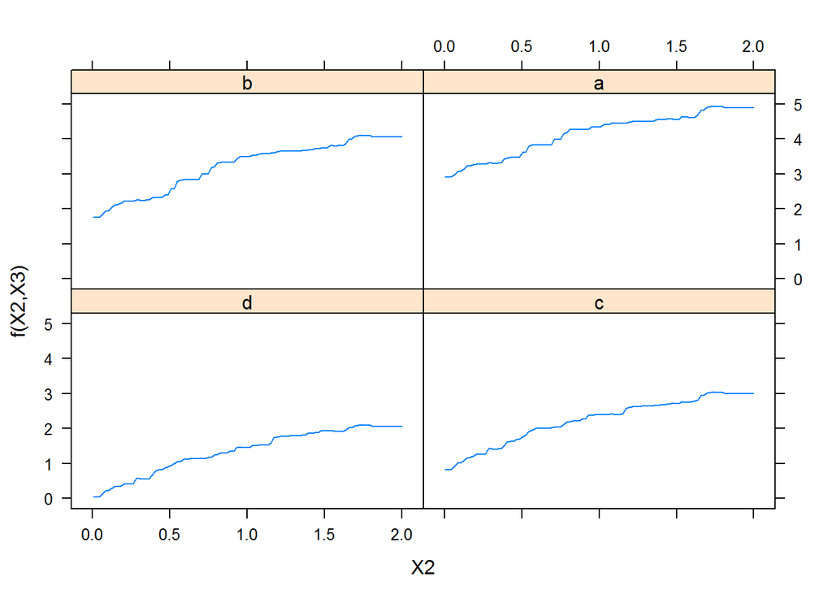

```r
# lattice plot of variables 2 and 3
plot(gbm1,2:3,best.iter)
```

```r
# lattice plot of variables 3 and 4
#plot(gbm1,3:4,best.iter)
```

### Versatility of use

```r
# do another 100 iterations
gbm2 <- gbm.more(gbm1,100,
                 verbose=FALSE) # stop printing detailed progress
```

## Competing Software

1. xgboost
2. lightGBM
3. h20

## xgboost

Authors: Tianqi Chen, Tong He, Michael Benesty

Backend: C++

The [xgboost](https://cran.r-project.org/web/packages/xgboost/index.html) R package provides an R API to “Extreme Gradient Boosting”, which is an efficient implementation of gradient boosting framework. [Parameter tuning guide](http://www.analyticsvidhya.com/blog/2016/03/complete-guide-parameter-%20tuning-xgboost-with-codes-python/) and more resources [here](https://github.com/dmlc/xgboost/tree/master/demo). The xgboost package is quite popular on [Kaggle](http://blog.kaggle.com/tag/xgboost/) for data mining competitions.

Features: - Stochastic GBM with column and row sampling (per split and per tree) for better generalization. - Includes efficient linear model solver and tree learning algorithms. - Parallel computation on a single machine. - Supports various objective functions, including regression, classification and ranking. - The package is made to be extensible, so that users are also allowed to define their own objectives easily. - Apache 2.0 License.

```r
library(xgboost)
```

## Practical Tips

- It’s more common to grow shorter trees (“shrubs” or “stumps”) in GBM than you do in Random Forest.
- It’s useful to try a variety of column sample (and column sample per tree) rates.
- Don’t assume that the set of optimal tuning parameters for one implementation of GBM will carry over and also be optimal in a different GBM implementation.

## Resources

- Trevor Hastie - Gradient Boosting & Random Forests at H2O World 2014 (YouTube)
- [Trevor Hastie - Data Science of GBM (2013)](http://www.slideshare.net/0xdata/gbm-27891077) (slides)
- [Mark Landry - Gradient Boosting Method and Random Forest at H2O World 2015](https://www.youtube.com/watch?v=9wn1f-30_ZY) (YouTube)
- [Peter Prettenhofer - Gradient Boosted Regression Trees in scikit-learn at PyData London 2014](https://www.youtube.com/watch?v=IXZKgIsZRm0) (YouTube)
- [Alexey Natekin1 and Alois Knoll - Gradient boosting machines, a tutorial](http://journal.frontiersin.org/article/10.3389/fnbot.2013.00021/full) (blog post)

## benchmark submission

```r
gbmFit = gbm(SalePrice ~ ., data = train)
summary(gbmFit)
preds = predict(gbmFit, test)
subMiss = cbind.data.frame(Id= test$Id,SalePrice= preds)
write.csv(subMiss, "C:/DatenLoecher/kaggle/HousePrices/data/GBMsubmission.csv", quote=F, row.names = FALSE)
```

## Summarize the missing values in the data.

- Alley: indicates the type of alley access
- FirePlaceQu: FirePlace Quality
- PoolQC: Pool Quality
- Fence: Fence Quality
- MiscFeature: Miscellaneous features not covered in other categories

The missing values indicate that majority of the houses do not have alley access, no pool, no fence and no elevator, 2nd garage, shed or tennis court that is covered by the MiscFeature.

The numeric variables do not have as many missing values but there are still some present. There are 259 values for the LotFrontage, 8 missing values for MasVnrArea and 81 missing values for GarageYrBlt.

- LotFrontage: Linear feet of street connected to property
- GarageYrBlt: Year garage was built
- MasVnrArea: Masonry veener area in square feet

Definition of Masonry Veener from google: Veneer masonry is a popular choice for home building and remodeling, because it gives the appearance of a solid brick or stone wall while providing better economy and insulation. It can be used as an addition to conventional wood frame structures, and can be placed on concrete block walls.

Brick veeners are not essential to the stucture of the house but are used to chance the appearance of the wall while providing better insulation. They tend to only have one brick layer.